# ClockSHAP introduction (GTEx-LUNG)

Anchored age scatter, positive and negative deviator waterfalls, and per-value mechanism

Pan-cancer aging project

August 13, 2026

```r
suppressPackageStartupMessages({
  library(dplyr)
  library(tibble)
  library(tidyr)
  library(readr)
  library(ggplot2)
  library(grid)        # unit(), arrow()
  library(here)

  library(glmnet)
  library(ClockSHAP)
})
```

# 1 — Load LUNG clock + ClockSHAP infrastructure

```r
tcga_project <- params$tcga_project
gtex_project <- params$gtex_project
feature_set  <- params$feature_set
base_dir     <- params$base_dir

analysis_id  <- paste0(tcga_project, "__", gtex_project)
analysis_dir <- file.path(here::here(base_dir), analysis_id)
suffix       <- paste0("-", feature_set)

clock_rds       <- file.path(analysis_dir, paste0("clock_and_RAA_objects", suffix, ".rds"))
clockshap_rds   <- file.path(analysis_dir, paste0("clockshap_objects",     suffix, ".rds"))
metadata_rds    <- file.path(analysis_dir, "sample_metadata.rds")
scores_gtex_rds <- file.path(analysis_dir, paste0("ssgsea_scores_gtex", suffix, ".rds"))

stopifnot(
  file.exists(clock_rds),
  file.exists(clockshap_rds),
  file.exists(metadata_rds),
  file.exists(scores_gtex_rds)
)

clock_results    <- readRDS(clock_rds)
clockshap_bundle <- readRDS(clockshap_rds)
metadata         <- readRDS(metadata_rds)
scores_gtex      <- readRDS(scores_gtex_rds)

feat <- clock_results$feature_names
stopifnot(all(feat %in% rownames(scores_gtex)))

message("LUNG clock features: ", length(feat),
        " | GTEx-LUNG ssGSEA samples: ", ncol(scores_gtex))
```

# 2 — GTEx reference line (anchoring coefficients)

```r
pred_gtex <- clock_results$pred$GTEx
age_gtex  <- clock_results$age$GTEx[names(pred_gtex)]

ok_g       <- complete.cases(pred_gtex, age_gtex)
pred_gtex  <- pred_gtex[ok_g]
age_gtex   <- age_gtex[ok_g]

bias_fit <- lm(pred_gtex ~ age_gtex)
beta0    <- coef(bias_fit)[1]
beta1    <- coef(bias_fit)[2]

c(beta0 = unname(beta0), beta1 = unname(beta1), n_gtex = length(pred_gtex))
```

```
##       beta0       beta1      n_gtex
##  44.4456048   0.1719702 655.0000000
```

# 3 — ClockSHAP on GTEx-LUNG

```r
X_gtex_full <- t(scores_gtex[feat, , drop = FALSE])

ids_keep      <- intersect(rownames(X_gtex_full), names(age_gtex))
X_gtex_cs     <- X_gtex_full[ids_keep, , drop = FALSE]
age_gtex_cs   <- as.numeric(age_gtex[ids_keep]); names(age_gtex_cs) <- ids_keep

clock_cs  <- clockshap_bundle$clock
reference <- clockshap_bundle$reference

cs_gtex <- ClockSHAP::clockshap(
  features  = X_gtex_cs,
  age       = age_gtex_cs,
  clock     = clock_cs,
  reference = reference
)

inv_max <- max(abs(rowSums(cs_gtex$phi) - cs_gtex$deviation), na.rm = TRUE)
message("GTEx-LUNG ClockSHAP invariant max |rowSums(phi) - deviation| = ", signif(inv_max, 3))
stopifnot(inv_max < 1e-8)
```

```r
# Sanity: ClockSHAP "expected" should equal the GTEx pred-line at each sample's age.
exp_recon <- beta0 + beta1 * cs_gtex$age
d_dev <- max(abs(cs_gtex$deviation - (cs_gtex$predicted - exp_recon)), na.rm = TRUE)
message(sprintf("[GTEx-LUNG] max|dev-(pred-line)| = %.3g", d_dev))
stopifnot(d_dev < 1e-6)
```

# 4 — Clock metrics + deviation summary

```r
metrics_tbl <- tibble(
  cohort = "GTEx-LUNG",
  n      = length(pred_gtex),
  r      = cor(pred_gtex, age_gtex),
  MAE    = mean(abs(pred_gtex - age_gtex)),
  mean_deviation = mean(cs_gtex$deviation, na.rm = TRUE),
  sd_deviation   = sd(cs_gtex$deviation, na.rm = TRUE)
)
knitr::kable(metrics_tbl, digits = 3,
             caption = "Clock fit (GTEx) + ClockSHAP deviation summary.")
```

Clock fit (GTEx) + ClockSHAP deviation summary.

| cohort | n | r | MAE | mean_deviation | sd_deviation |
| --- | --- | --- | --- | --- | --- |
| GTEx-LUNG | 655 | 0.465 | 8.487 | 0 | 3.93 |

```r
out_dir <- here::here(params$fig_dir)
if (isTRUE(params$save_figures)) dir.create(out_dir, recursive = TRUE, showWarnings = FALSE)
```

# 5 — Pick representative samples

```r
pick_waterfall_sample <- function(cs, dev_q, top_n = 8, min_bar = 2.0, exclude = character()) {
  phi <- cs$phi; ids <- rownames(phi)
  ok  <- is.finite(cs$deviation) & is.finite(cs$expected) & is.finite(cs$predicted)
  phi <- phi[ok, , drop = FALSE]; dev <- cs$deviation[ok]; ids <- ids[ok]

  keep_excl <- !(ids %in% exclude)
  phi <- phi[keep_excl, , drop = FALSE]; dev <- dev[keep_excl]; ids <- ids[keep_excl]

  lo <- unname(stats::quantile(dev, dev_q[1], na.rm = TRUE))
  hi <- unname(stats::quantile(dev, dev_q[2], na.rm = TRUE))
  keep <- dev >= lo & dev <= hi
  phi2 <- phi[keep, , drop = FALSE]; ids2 <- ids[keep]
  if (nrow(phi2) == 0) stop("No samples left after dev_q filtering.", call. = FALSE)

  top_abs  <- t(apply(abs(phi2), 1, function(v) sort(v, decreasing = TRUE)[seq_len(top_n)]))
  min_top  <- apply(top_abs, 1, min); mean_top <- rowMeans(top_abs)
  cand <- which(min_top >= min_bar); if (length(cand) == 0) cand <- seq_len(nrow(phi2))
  ids2[cand[which.max(mean_top[cand])]]
}

# Hand-picked GTEx deviators: POSITIVE (red) and NEGATIVE (blue).
sample_neg <- "GTEX-QDVN-0726-SM-4B64L.1"   # negative deviator (blue)
sample_pos <- "GTEX-13JUV-0526-SM-5K7XE.1"  # positive deviator (red)

# ---- To override any pick manually, uncomment and set IDs: ----
# sample_neg <- "GTEX-XXXXX-..."
# sample_pos <- "GTEX-XXXXX-..."

pick_one <- function(cs, sid, label) {
  i <- match(sid, rownames(cs$phi))
  tibble(panel = label, sample_id = sid,
         age = cs$age[i], predicted = cs$predicted[i],
         expected = cs$expected[i], deviation = cs$deviation[i])
}
knitr::kable(bind_rows(
  pick_one(cs_gtex, sample_pos, "GTEx pos"),
  pick_one(cs_gtex, sample_neg, "GTEx neg")
), digits = 2, caption = "Selected representative samples.")
```

Selected representative samples.

| panel | sample_id | age | predicted | expected | deviation |
| --- | --- | --- | --- | --- | --- |
| GTEx pos | GTEX-13JUV-0526-SM-5K7XE.1 | 46 | 57.03 | 52.36 | 4.67 |
| GTEx neg | GTEX-QDVN-0726-SM-4B64L.1 | 56 | 49.13 | 54.08 | -4.94 |

# GTEx-LUNG: predicted vs chronological age

GTEx-LUNG on the anchored axis (`age + deviation`). The dashed identity line is the cohort expectation; the cohort sits on it (mean deviation 0 by construction). Two representative samples are highlighted (positive = red; negative = blue), each with a grey vertical segment to the identity line, labelled with its deviation. Each drives one of the waterfalls below.

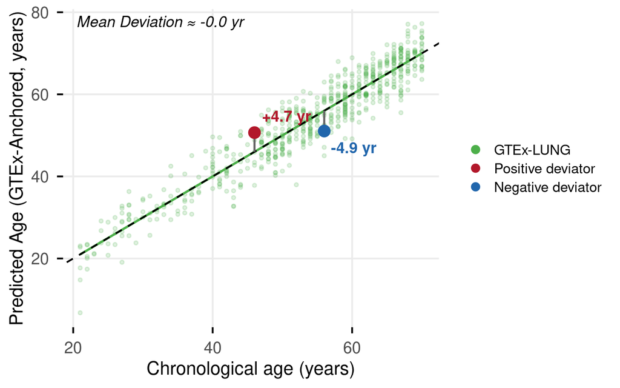

```r
cohort_pal <- c("GTEx-LUNG" = "#4daf4a", "LUAD-NAT" = "darkorange")

# Combined legend palette: cohort + the two deviator directions in one scale.
legend_pal <- c(
  "GTEx-LUNG"                   = unname(cohort_pal[["GTEx-LUNG"]]),
  "Positive deviator" = "#b2182b",
  "Negative deviator" = "#2166ac"
)

gtex_df <- tibble(
  sample_id     = rownames(cs_gtex$phi),
  age_years     = as.numeric(cs_gtex$age),
  pred_anchored = as.numeric(cs_gtex$age + cs_gtex$deviation)
) %>%
  filter(complete.cases(age_years, pred_anchored)) %>%
  mutate(highlight = case_when(
    sample_id == sample_pos ~ "positive",
    sample_id == sample_neg ~ "negative",
    TRUE                    ~ "other"
  ))

# Highlighted deviators carry their direction as the legend group
gtex_hl <- gtex_df %>% filter(highlight != "other") %>%
  mutate(legend_group = ifelse(highlight == "positive",
                               "Positive deviator",
                               "Negative deviator"),
         deviation  = pred_anchored - age_years,
         label_text = sprintf("%+.1f yr", deviation),
         label_y    = ifelse(highlight == "positive", pred_anchored + 4, pred_anchored - 4))

# Background cloud carries the cohort as its legend group
gtex_bg <- gtex_df %>% mutate(legend_group = "GTEx-LUNG")

gtex_mean_dev <- mean(cs_gtex$deviation, na.rm = TRUE)
common_breaks <- c(20, 40, 60, 80)

p_panelA <- ggplot() +
  geom_point(data = gtex_bg, aes(age_years, pred_anchored, colour = legend_group),
             alpha = 0.18, size = 1.2) +
  geom_smooth(data = gtex_bg, aes(age_years, pred_anchored),
              method = "lm", se = FALSE, colour = cohort_pal[["GTEx-LUNG"]], linewidth = 1.0) +
  geom_abline(slope = 1, intercept = 0, linetype = "dashed", colour = "black") +
  geom_segment(data = gtex_hl,
               aes(x = age_years, y = pred_anchored, xend = age_years, yend = age_years),
               colour = "grey40", linewidth = 0.9) +
  geom_point(data = gtex_hl, aes(age_years, pred_anchored, colour = legend_group), size = 4.5) +
  geom_text(data = gtex_hl, aes(age_years, label_y, label = label_text, colour = legend_group),
            fontface = "bold", size = 5, hjust = -0.15, show.legend = FALSE) +
  annotate("text", x = -Inf, y = Inf,
           label = sprintf("Mean Deviation \u2248 %.1f yr", gtex_mean_dev),
           hjust = -0.08, vjust = 1.6, size = 5, fontface = "italic") +
  scale_colour_manual(values = legend_pal, name = NULL,
                      breaks = c("GTEx-LUNG",
                                 "Positive deviator",
                                 "Negative deviator")) +
  guides(colour = guide_legend(override.aes = list(alpha = 1, size = 3))) +
  scale_x_continuous(breaks = common_breaks) +
  scale_y_continuous(breaks = common_breaks) +
  labs(x = "Chronological age (years)", y = "Predicted Age (GTEx-Anchored, years)") +
  theme_minimal(base_size = 17) +
  theme(legend.position = "right", legend.title = element_blank(),
        panel.grid.minor = element_blank(), axis.ticks = element_line(),
        axis.ticks.length = unit(2, "mm"), axis.title = element_text(size = 17),
        axis.text = element_text(size = 15), legend.text = element_text(size = 13))
p_panelA
```

```r
if (isTRUE(params$save_figures)) {
  ggsave(file.path(out_dir, "GTEx_LUNG_scatter.pdf"), p_panelA,
         width = 220/25.4, height = 130/25.4, units = "in")
  message("Saved: GTEx_LUNG_scatter.pdf")
}
```

# GTEx-LUNG: positive-deviator ClockSHAP waterfall

Decomposition of the positive-deviator GTEx sample (red in the anchored scatter) into pathway contributions summing to its age-matched deviation.

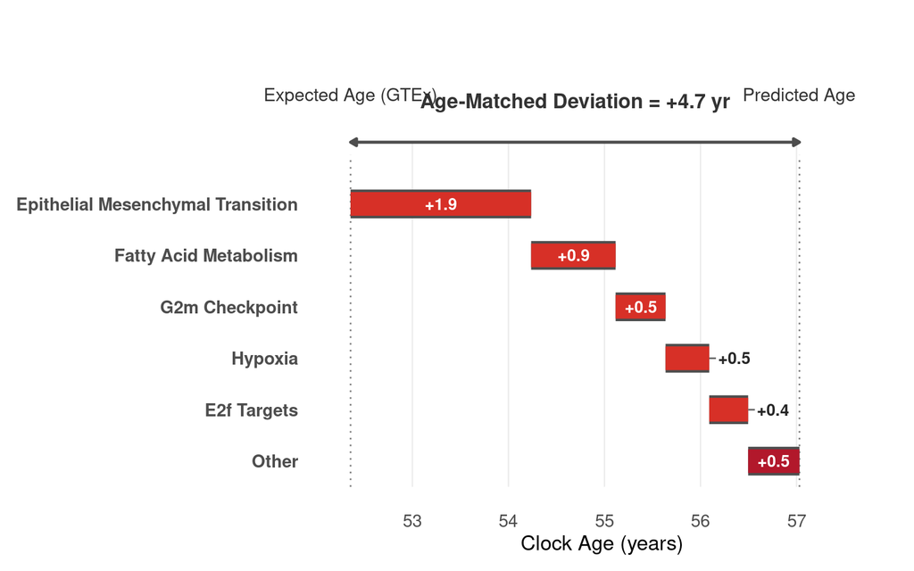

```r
wf_common <- function(cs, sid) {
  plot_clockshap_waterfall(
    x = cs, sample = sid, top_n = params$waterfall_top_n,
    show_age_labels = TRUE, show_delta_label = TRUE, show_effect_labels = TRUE, effect_label_min_frac = 0.1,
    x_axis_title = "Clock Age (years)", y_axis_title = NULL,
    deviation_label = "Age-Matched Deviation = {value} yr",
    expected_age_label = "Expected Age (GTEx)",
    predicted_age_label = "Predicted Age",
    effect_label = "{value}"
  ) + theme(axis.title.x = element_text(size = 13),
            axis.text.x = element_text(size = 11), axis.text.y = element_text(size = 11),
            plot.margin = margin(t = 20, r = 10, b = 10, l = 10))
}

p_panelB <- wf_common(cs_gtex, sample_pos)
p_panelB
```

```r
if (isTRUE(params$save_figures)) {
  ggsave(file.path(out_dir, "GTEx_LUNG_waterfall_pos.pdf"), p_panelB,
         width = 180/25.4, height = 90/25.4, units = "in")
  message("Saved: GTEx_LUNG_waterfall_pos.pdf")
}
```

# GTEx-LUNG: negative-deviator ClockSHAP waterfall

Decomposition of the negative-deviator GTEx sample (blue in the anchored scatter). Contrasting the two waterfalls shows that individual decompositions differ by sample and by direction — ClockSHAP captures per-sample heterogeneity.

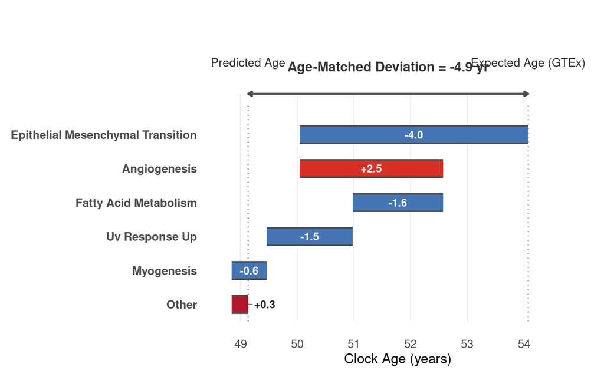

```r
p_panelC <- wf_common(cs_gtex, sample_neg)
p_panelC
```

```r
if (isTRUE(params$save_figures)) {
  ggsave(file.path(out_dir, "GTEx_LUNG_waterfall_neg.pdf"), p_panelC,
         width = 180/25.4, height = 90/25.4, units = "in")
  message("Saved: GTEx_LUNG_waterfall_neg.pdf")
}
```

# Under the hood: what a single ClockSHAP value is

What a single ClockSHAP value is, demonstrated on one pathway (EMT). The line is the GTEx age trend `E[X_EMT|Age]`; the gap from line to point, times the clock weight, gives the φ in years. The two highlighted samples sit on opposite sides of the line, so the *same* pathway contributes a positive value for one (red) and a negative value for the other (blue). The formal equation lives next to this plot in the assembled figure.

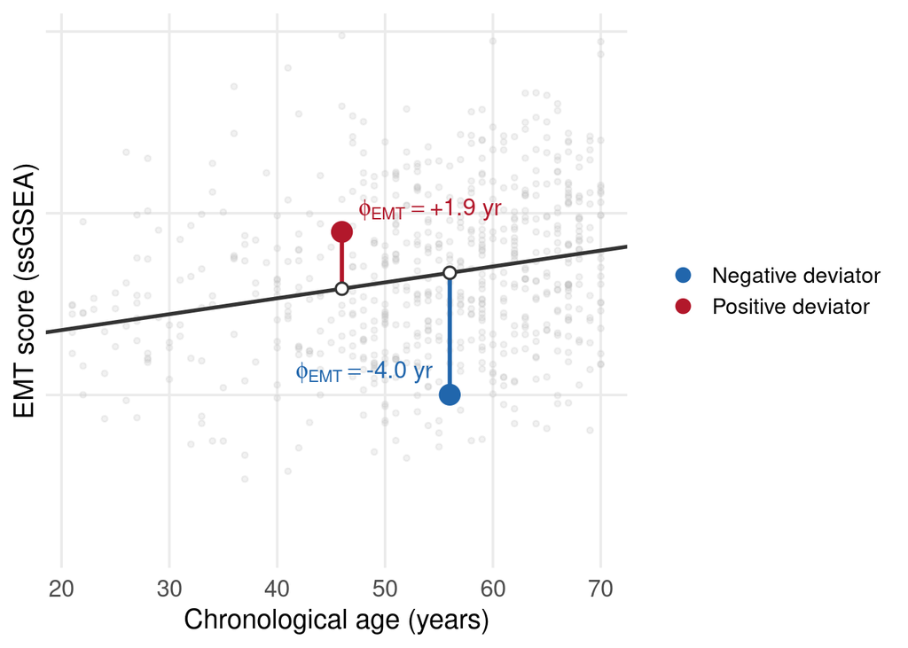

```r
# --- Resolve the mechanism pathway (EMT) and its effective raw-scale weight ---
emt_name <- if (params$mech_pathway %in% feat) params$mech_pathway else grep("Mesenchymal", feat, value = TRUE)[1]
stopifnot(!is.na(emt_name), emt_name %in% feat)

cs_params <- clock_results$clock_cs
beta_k  <- cs_params$beta;  if (is.null(names(beta_k)))  names(beta_k)  <- feat
sigma_k <- cs_params$sigma; if (is.null(names(sigma_k))) names(sigma_k) <- feat
w_emt   <- as.numeric(beta_k[emt_name] / sigma_k[emt_name])

# --- GTEx EMT scores vs age + age-conditioned reference line E[X_EMT|Age] ---
emt_ids  <- rownames(cs_gtex$phi)
emt_gtex <- tibble(
  sample_id = emt_ids,
  age       = as.numeric(cs_gtex$age),
  emt_obs   = X_gtex_cs[emt_ids, emt_name]
) %>% filter(complete.cases(age, emt_obs))

emt_fit <- lm(emt_obs ~ age, data = emt_gtex)
g0_emt  <- unname(coef(emt_fit)[1]); g1_emt <- unname(coef(emt_fit)[2])

# QA: reconstructed phi must match ClockSHAP phi for EMT
emt_gtex <- emt_gtex %>%
  mutate(emt_exp   = g0_emt + g1_emt * age,
         phi_recon = w_emt * (emt_obs - emt_exp),
         phi_cs    = cs_gtex$phi[sample_id, emt_name])
phi_err <- max(abs(emt_gtex$phi_recon - emt_gtex$phi_cs), na.rm = TRUE)
message(sprintf("EMT phi reconstruction max abs error = %.3g (should be ~0)", phi_err))
stopifnot(phi_err < 1e-6)

# --- Two highlighted samples: positive (red) and negative (blue) ---
dir_pal <- c("Positive deviator" = "#b2182b",
             "Negative deviator" = "#2166ac")
hl <- emt_gtex %>%
  filter(sample_id %in% c(sample_pos, sample_neg)) %>%
  mutate(direction = ifelse(sample_id == sample_pos,
                            "Positive deviator", "Negative deviator"),
         phi_lab  = sprintf('phi[EMT] == "%+.1f yr"', phi_cs),
         lab_h    = ifelse(sample_id == sample_pos, -0.12, 1.12))

p_panelD <- ggplot() +
  # GTEx cloud
  geom_point(data = emt_gtex, aes(age, emt_obs), colour = "grey75", alpha = 0.22, size = 1.1) +
  # E[X_EMT | Age] reference line (no label here — add in AI if you want it)
  geom_abline(slope = g1_emt, intercept = g0_emt, colour = "grey20", linewidth = 1.0) +
  # gaps: expected -> observed, coloured by direction
  geom_segment(data = hl, aes(x = age, xend = age, y = emt_exp, yend = emt_obs, colour = direction),
               linewidth = 1.1, show.legend = FALSE) +
  # expected points (open, on line) + observed points (filled)
  geom_point(data = hl, aes(age, emt_exp), shape = 21, fill = "white", colour = "grey20",
             size = 2.6, stroke = 0.9) +
  geom_point(data = hl, aes(age, emt_obs, colour = direction), size = 4.8) +
  # phi value labels (parsed plotmath)
  geom_text(data = hl, aes(age, emt_obs, label = phi_lab, colour = direction, hjust = lab_h),
            parse = TRUE, fontface = "bold", size = 4.6, vjust = -0.5, show.legend = FALSE) +
  scale_y_continuous(expand = expansion(mult = c(0.20, 0.05))) +
  scale_colour_manual(values = dir_pal, name = NULL) +
  guides(colour = guide_legend(override.aes = list(size = 3.2))) +
  labs(x = "Chronological age (years)",
       y = "EMT score (ssGSEA)") +
  theme_minimal(base_size = 15) +
  theme(panel.grid.minor = element_blank(),
        legend.position = "right", legend.title = element_blank(),
        legend.text = element_text(size = 12),
        axis.title = element_text(size = 15),
        axis.text.x = element_text(size = 13),
        axis.text.y = element_blank(),
        axis.ticks.y = element_blank())
p_panelD
```

```r
if (isTRUE(params$save_figures)) {
  ggsave(file.path(out_dir, "EMT_mechanism.pdf"), p_panelD,
         width = 175/25.4, height = 125/25.4, units = "in")
  message("Saved: EMT_mechanism.pdf")
}
```